# Chapter 2: Regression and model validation

*First look at data wrangling and analysis*

## Data wrangling

Reading the full data and naming it “learning2014”.

```r
learning2014 <- read.table("http://www.helsinki.fi/~kvehkala/JYTmooc/JYTOPKYS3-data.txt", sep="\t", header = TRUE)
```

Data consists of 183 rows (observations) and 60 columns (variables).

```r
dim(learning2014)
```

```
## [1] 183  60
```

The structure of the data:

```r
str(learning2014)
```

```
## 'data.frame':    183 obs. of  60 variables:
##  $ Aa      : int  3 2 4 4 3 4 4 3 2 3 ...
##  $ Ab      : int  1 2 1 2 2 2 1 1 1 2 ...
##  $ Ac      : int  2 2 1 3 2 1 2 2 2 1 ...
##  $ Ad      : int  1 2 1 2 1 1 2 1 1 1 ...
##  $ Ae      : int  1 1 1 1 2 1 1 1 1 1 ...
##  $ Af      : int  1 1 1 1 1 1 1 1 1 2 ...
##  $ ST01    : int  4 4 3 3 4 4 5 4 4 4 ...
##  $ SU02    : int  2 2 1 3 2 3 2 2 1 2 ...
##  $ D03     : int  4 4 4 4 5 5 4 4 5 4 ...
##  $ ST04    : int  4 4 4 4 3 4 2 5 5 4 ...
##  $ SU05    : int  2 4 2 3 4 3 2 4 2 4 ...
##  $ D06     : int  4 2 3 4 4 5 3 3 4 4 ...
##  $ D07     : int  4 3 4 4 4 5 4 4 5 4 ...
##  $ SU08    : int  3 4 1 2 3 4 4 2 4 2 ...
```

[output cut: 46 more lines]

Acces the dplyr library:

```r
library(dplyr)
```

Combinig the questions related to deep, surface and strategic learning.

```r
deep_questions <- c("D03", "D11", "D19", "D27", "D07", "D14", "D22", "D30","D07","D14","D22","D30")
surface_questions <-c("SU02","SU10","SU18","SU26", "SU05","SU13","SU21","SU29","SU08","SU16","SU24","SU32")
strategic_questions <- c("ST01","ST09","ST17","ST25","ST04","ST12","ST20","ST28")
```

Selecting the columns for “deep” and taking average to scale the variable.

```r
deep_columns <- select(learning2014, one_of(deep_questions))
learning2014$deep <- rowMeans(deep_columns)
```

Selecting the columns for “surf” and taking average to scale the variable.

```r
surface_columns <- select(learning2014, one_of(surface_questions))
learning2014$surf <- rowMeans(surface_columns)
```

Selecting the columns for “stra” and taking average to scale the variable.

```r
strategic_columns <- select(learning2014, one_of(strategic_questions))
learning2014$stra <- rowMeans(strategic_columns)
```

Selecting the variables gender, age, attitude towards statistics, exam points and the three new summary variables to dataset.

```r
keep_columns <- c("gender", "Age", "Attitude", "deep", "stra", "surf", "Points")
new_learning2014 <- select(learning2014, one_of(keep_columns))
```

Removing the observations with 0 exam points:

```r
new_learning2014 <- filter(new_learning2014, Points > 0)
```

Testing: The dimension and structure seem to be correct.

```r
dim(new_learning2014)
```

```
## [1] 166   7
```

```r
str(new_learning2014)
```

```
## 'data.frame':    166 obs. of  7 variables:
##  $ gender  : Factor w/ 2 levels "F","M": 1 2 1 2 2 1 2 1 2 1 ...
##  $ Age     : int  53 55 49 53 49 38 50 37 37 42 ...
##  $ Attitude: int  37 31 25 35 37 38 35 29 38 21 ...
##  $ deep    : num  3.75 2.88 3.88 3.5 3.75 ...
##  $ stra    : num  3.38 2.75 3.62 3.12 3.62 ...
##  $ surf    : num  2.58 3.17 2.25 2.25 2.83 ...
##  $ Points  : int  25 12 24 10 22 21 21 31 24 26 ...
```

Saving the dataset:

```r
write.table(new_learning2014, "learning2014.txt", sep = "\t")
```

```r
str(new_learning2014)
```

```
## 'data.frame':    166 obs. of  7 variables:
##  $ gender  : Factor w/ 2 levels "F","M": 1 2 1 2 2 1 2 1 2 1 ...
##  $ Age     : int  53 55 49 53 49 38 50 37 37 42 ...
##  $ Attitude: int  37 31 25 35 37 38 35 29 38 21 ...
##  $ deep    : num  3.75 2.88 3.88 3.5 3.75 ...
##  $ stra    : num  3.38 2.75 3.62 3.12 3.62 ...
##  $ surf    : num  2.58 3.17 2.25 2.25 2.83 ...
##  $ Points  : int  25 12 24 10 22 21 21 31 24 26 ...
```

```r
dim(new_learning2014)
```

```
## [1] 166   7
```

```r
head(new_learning2014)
```

```
##   gender Age Attitude  deep  stra     surf Points
## 1      F  53       37 3.750 3.375 2.583333     25
## 2      M  55       31 2.875 2.750 3.166667     12
## 3      F  49       25 3.875 3.625 2.250000     24
## 4      M  53       35 3.500 3.125 2.250000     10
## 5      M  49       37 3.750 3.625 2.833333     22
## 6      F  38       38 4.875 3.625 2.416667     21
```

…and everything seems to be ok and I’m able move forward to the analysis part of the exercises.

## Analysis

1. Describing the data

I’m using the dataset from the previous part of the exercise. The data is part of a larger “Approaches to Learning” -survey. Here is used only a few backgroud variables (age and gender), variable measuring global attitude toward statistics, exam points and sum variables measuring student’s deep, surface and strategic learning.

When observations with zero exam points are excluded, the total N of the data is 166.

2. Descriptive statistics

First thing to do with the data is to see some descriptive statistics.

```r
summary(new_learning2014)
```

```
##  gender       Age           Attitude          deep            stra
##  F:110   Min.   :17.00   Min.   :14.00   Min.   :1.625   Min.   :1.250
##  M: 56   1st Qu.:21.00   1st Qu.:26.00   1st Qu.:3.500   1st Qu.:2.625
##          Median :22.00   Median :32.00   Median :3.875   Median :3.188
##          Mean   :25.51   Mean   :31.43   Mean   :3.796   Mean   :3.121
##          3rd Qu.:27.00   3rd Qu.:37.00   3rd Qu.:4.250   3rd Qu.:3.625
##          Max.   :55.00   Max.   :50.00   Max.   :4.875   Max.   :5.000
##       surf           Points
##  Min.   :1.583   Min.   : 7.00
##  1st Qu.:2.417   1st Qu.:19.00
##  Median :2.833   Median :23.00
##  Mean   :2.787   Mean   :22.72
##  3rd Qu.:3.167   3rd Qu.:27.75
##  Max.   :4.333   Max.   :33.00
```

There are 110 female and 56 male respondents in the data. Tha average age is 25.5 when the youngest respondent is 17 and the oldest 55 years old. The measured mean attitude towards statistics is 31.4, ranging from 14 to 50. Exam points range (when 0 points excluded) from 7 to 33 and the average is 22.7. The summary variables measuring deep, strategic and surface learning are scaled from 1 to 5. In deep learning the averige is 3.8 (minimum 1.6, maximum 4.9), strategic learning 3.1 (min 1.3, max 5.0) and surface learning 2.8 (min 1.6, max 4.3).

As a graphical overview I made a scatter plot of all the variables according to background variables.

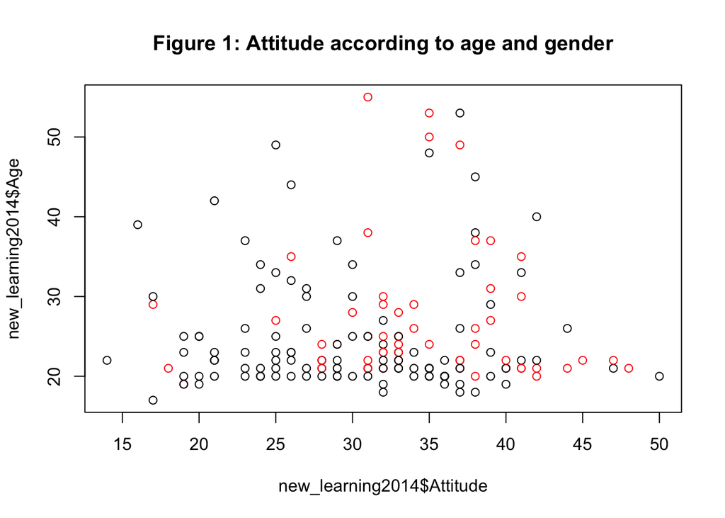

```r
plot(new_learning2014$Attitude, new_learning2014$Age, col=new_learning2014$gender, title("Figure 1: Attitude according to age and gender"))
```

Males and older respondents seem to have more attitude towards statistics.

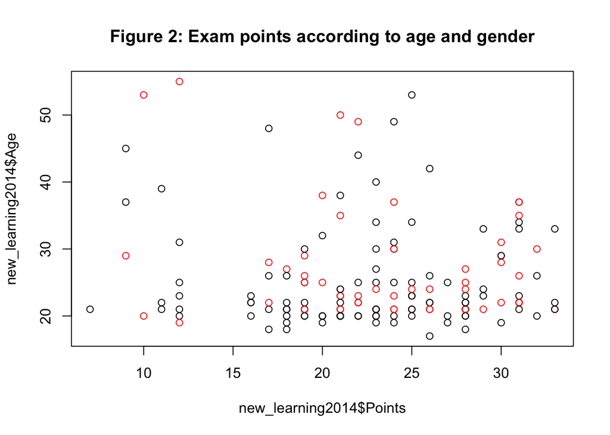

```r
plot(new_learning2014$Points, new_learning2014$Age, col=new_learning2014$gender, title("Figure 2: Exam points according to age and gender"))
```

There is a lot of variation in exam points, no clear trends visible. Especially in the lower points there are both genders and respondents of all ages represent.

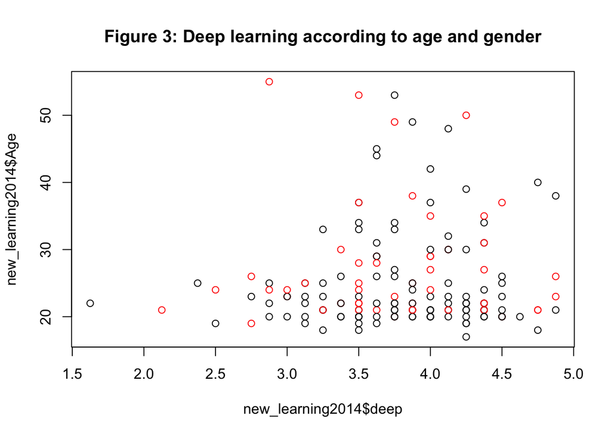

```r
plot(new_learning2014$deep, new_learning2014$Age, col=new_learning2014$gender, title("Figure 3: Deep learning according to age and gender"))
```

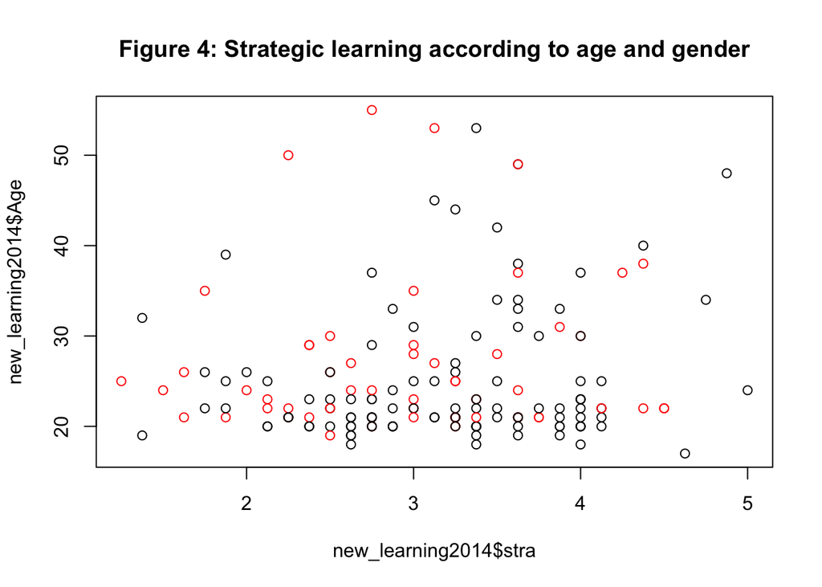

```r
plot(new_learning2014$stra, new_learning2014$Age, col=new_learning2014$gender, title("Figure 4: Strategic learning according to age and gender"))
```

In strategic learning the impact of age is not at visible as above, but some connection is visible.

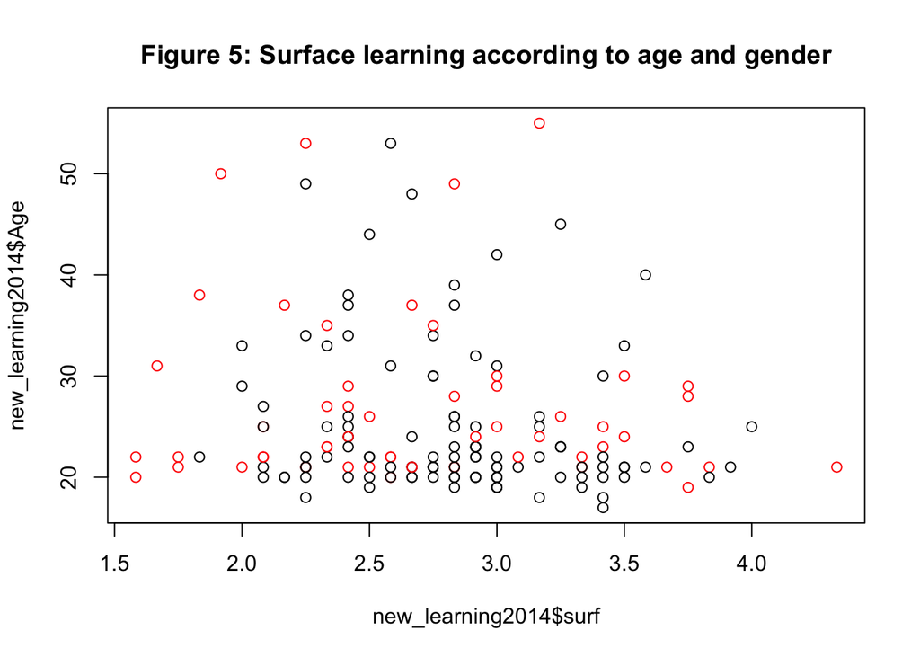

```r
plot(new_learning2014$surf, new_learning2014$Age, col=new_learning2014$gender, title("Figure 5: Surface learning according to age and gender"))
```

Surface learning is less usual than the other two, but surprisingly there are no clear differences according to age nor gender.

3. Regression model

Creating a regression model with three explanatory variables (attitude, deep learning and strategic learning). The dependent variable is exam points. Checking the summary of the model.

```r
rg_model <- lm(Points ~ Attitude + deep + stra, data = new_learning2014)
summary(rg_model)
```

```
##
## Call:
## lm(formula = Points ~ Attitude + deep + stra, data = new_learning2014)
##
## Residuals:
##     Min      1Q  Median      3Q     Max
## -17.525  -3.342   0.572   3.902  11.646
##
## Coefficients:
##             Estimate Std. Error t value Pr(>|t|)
## (Intercept) 12.05207    3.43928   3.504 0.000592 ***
## Attitude     0.35116    0.05654   6.211 4.27e-09 ***
## deep        -0.90243    0.72430  -1.246 0.214584
## stra         0.97852    0.53610   1.825 0.069805 .
## ---
## Signif. codes:  0 '***' 0.001 '**' 0.01 '*' 0.05 '.' 0.1 ' ' 1
##
## Residual standard error: 5.28 on 162 degrees of freedom
## Multiple R-squared:  0.2124, Adjusted R-squared:  0.1978
## F-statistic: 14.56 on 3 and 162 DF,  p-value: 1.925e-08
```

The summary table tells us that when attitude rises one point the exam point increses by 0.35 points. The similar connecton with deep learning is -0.90 and with strategic learning 0.98.

The only statistically significant variable is the attitude. I tried surface learning and both age and gender as well, but they were not statistically significant in the analysis. In this case I remove all the other variables but the attitude.

4. Summary of the fitted model

The final regression model is simple with only one independet, explanatory variable.

```r
rg_model2 <- lm(Points ~ Attitude, data = new_learning2014)
summary(rg_model2)
```

```
##
## Call:
## lm(formula = Points ~ Attitude, data = new_learning2014)
##
## Residuals:
##      Min       1Q   Median       3Q      Max
## -16.9763  -3.2119   0.4339   4.1534  10.6645
##
## Coefficients:
##             Estimate Std. Error t value Pr(>|t|)
## (Intercept) 11.63715    1.83035   6.358 1.95e-09 ***
## Attitude     0.35255    0.05674   6.214 4.12e-09 ***
## ---
## Signif. codes:  0 '***' 0.001 '**' 0.01 '*' 0.05 '.' 0.1 ' ' 1
##
## Residual standard error: 5.32 on 164 degrees of freedom
## Multiple R-squared:  0.1906, Adjusted R-squared:  0.1856
## F-statistic: 38.61 on 1 and 164 DF,  p-value: 4.119e-09
```

The effect of attitude stays the same as above: when the level of attitude grows one point, the exam points increse by 0.35 points. The effect is not very strong, but it is statistically significant, which means that there is very low change to make the wrong assumption about the relationship of these two variables.

5. Diagnostic plots

Residuals vs. Fitted values:

In this diagnostic plot we examine if the errors are just errors and not depending on the explanatory variable. This means that there should not be any kind of pattern in the plot - and luckily there is not.

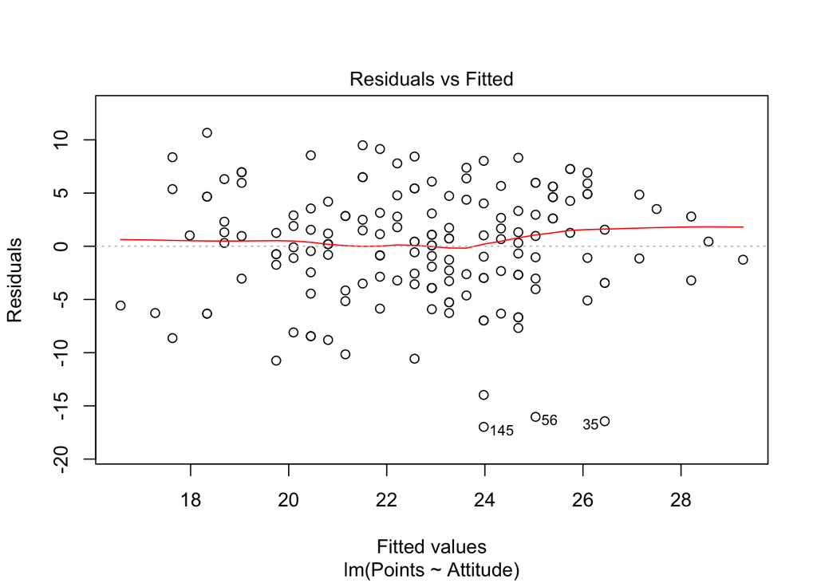

```r
plot(rg_model2, which = 1)
```

Normal QQ-plot:

The plot shows that the residuals are close enough normally distributed. The residuals follow the line quite well.

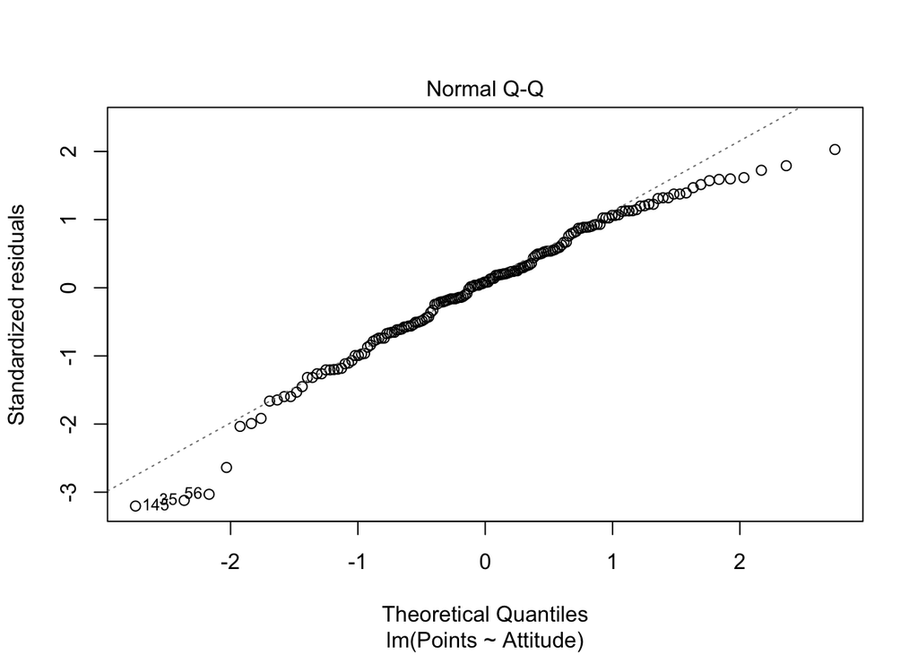

```r
plot(rg_model2, which = 2)
```

Residuals vs. Leverage:

In this plot we examine the impact of an individual observation on the model, basically by checking how far from the average are the (possible) observations that do not fit in the model. In this case there is nothing to worry.

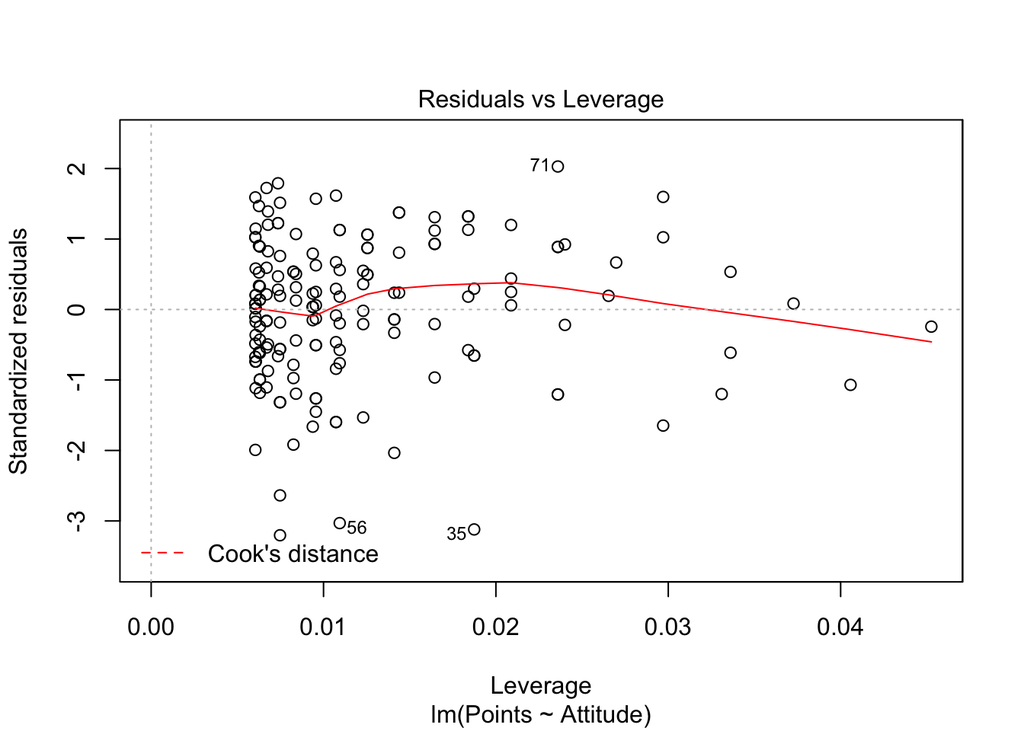

```r
plot(rg_model2, which = 5)
```